# HICKMAN’s Exam 3

## STEP I: Load and Clean the Data

The first step in the exam was to load a data set, “FacultySalaries_1995.csv,” and tidy it by combining several repeated variables. As you can see, the dataset is dirty indeed.

```r
dat <- read_csv("./../Exam_3/FacultySalaries_1995.csv")
glimpse(dat)
```

```
## Rows: 1,161
## Columns: 17
## $ FedID               <dbl> 1061, 1063, 1065, 11462, 1002, 1004, 1008, 1009, 1…
## $ UnivName            <chr> "Alaska Pacific University", "Univ.Alaska-Fairbank…
## $ State               <chr> "AK", "AK", "AK", "AK", "AL", "AL", "AL", "AL", "A…
## $ Tier                <chr> "IIB", "I", "IIA", "IIA", "IIA", "IIA", "IIB", "I"…
## $ AvgFullProfSalary   <dbl> 454, 686, 533, 612, 442, 441, 466, 580, 498, 506, …
## $ AvgAssocProfSalary  <dbl> 382, 560, 494, 507, 369, 385, 394, 437, 379, 412, …
## $ AvgAssistProfSalary <dbl> 362, 432, 329, 414, 310, 310, 351, 374, 322, 359, …
## $ AvgProfSalaryAll    <dbl> 382, 508, 415, 498, 350, 388, 396, 455, 401, 411, …
## $ AvgFullProfComp     <dbl> 567, 914, 716, 825, 530, 542, 558, 692, 655, 607, …
## $ AvgAssocProfComp    <dbl> 485, 753, 663, 681, 444, 473, 476, 527, 501, 508, …
## $ AvgAssistProfComp   <dbl> 471, 572, 442, 557, 376, 383, 427, 451, 404, 445, …
## $ AvgProfCompAll      <dbl> 487, 677, 559, 670, 423, 477, 478, 546, 523, 503, …
## $ NumFullProfs        <dbl> 6, 74, 9, 115, 59, 57, 20, 366, 34, 67, 8, 106, 27…
## $ NumAssocProfs       <dbl> 11, 125, 26, 124, 77, 33, 18, 354, 25, 40, 15, 42,…
## $ NumAssistProfs      <dbl> 9, 118, 20, 101, 102, 35, 30, 301, 27, 66, 19, 66,…
## $ NumInstructors      <dbl> 4, 40, 9, 21, 24, 2, 0, 66, 3, 27, 2, 58, 4, 19, 3…
## $ NumFacultyAll       <dbl> 32, 404, 70, 392, 262, 127, 68, 1109, 89, 200, 44,…
```

So I went about my business, combining more columns than was probably necessary for basal success. My goal? Recreating a subpar graph.

To achieve this feat, I had to get out my broom and cleaning supplies–praise the lord for pivot_longer!

```r
dat <- dat %>%
  pivot_longer(cols = c("AvgFullProfSalary", "AvgAssocProfSalary", "AvgAssistProfSalary"),
               names_to = "Rank",
               values_to = "Salary") %>%
  pivot_longer(cols = c("AvgFullProfComp", "AvgAssocProfComp", "AvgAssistProfComp"),
               names_to = "Rank_Comp",
               values_to = "Compensation") %>%
  pivot_longer(cols = c("NumFullProfs", "NumAssocProfs", "NumAssistProfs", "NumInstructors"),
               names_to = "Rank_Num",
               values_to = "Staff_Number") %>%
  mutate(Rank = case_when(Rank == "AvgFullProfSalary" ~ "Full",
                          Rank == "AvgAssocProfSalary" ~ "Assoc",
                          Rank == "AvgAssistProfSalary" ~ "Assist"))
```

Sweet success was my friend, but only after I realized that the fourth Tier was a poser. Yes, this faux category included but one university (which I’ve never heard of) with a particular gift for screwing up box plots. So I cut it out, like tissue rife with gangrene, using the sharp blade of subset.

```r
dat <- dat[!(dat$Tier=="VIIB"), ]
```

Once I passed this tribulation, I was free to graph as I pleased. And you can bet I did…

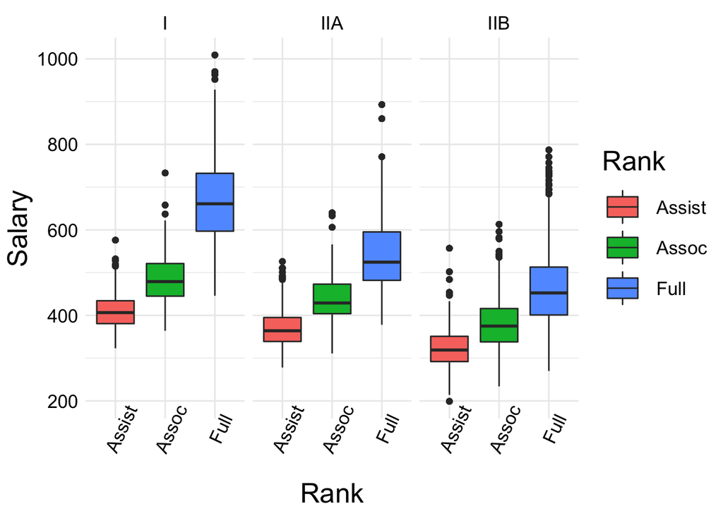

```r
dat %>%
  ggplot(aes(x=Rank,y=Salary)) +
  geom_boxplot(aes(fill=Rank)) +
  facet_wrap(~Tier) +
  theme_minimal() +
  theme(legend.key.size = unit(1, "cm"),
        legend.title = element_text(size = 19, color = "black"),
        legend.text = element_text(size = 13, color = "black"),
        axis.text.x = element_text(angle = 65, size = 13, color = "black"),
        axis.text.y = element_text(size = 13, color = "black"),
        axis.title.x = element_text(size = 19, color = "black"),
        axis.title.y = element_text(size = 19, color = "black"),
        strip.text.x = element_text(size = 13, color = "black"))
```

```r
ggsave("./HICKMAN_Fig_1.jpg")
```

After exporting my hard-earned treasure to a directory containing Exam_3.RProj, I was off on the second leg of my journey…

## STEP II: Export ANOVA file

To begin this second chapter, I needed to first have an ANOVA to export. Thus, I diligently created a model that would show the influence of several variables, but I neglected the distasteful interactions. Slow and simple wins the race, or so I hear.

```r
mod1 <- glm(data = dat,
            formula = Salary ~ State + Tier + Rank)
summary(mod1)
```

```
##
## Call:
## glm(formula = Salary ~ State + Tier + Rank, data = dat)
##
## Deviance Residuals:
##     Min       1Q   Median       3Q      Max
## -206.47   -36.31    -2.13    31.90   329.47
##
## Coefficients:
##              Estimate Std. Error  t value Pr(>|t|)
## (Intercept)  474.8303     5.0459   94.103  < 2e-16 ***
## StateAL      -70.5033     5.4425  -12.954  < 2e-16 ***
## StateAR      -55.2513     5.6189   -9.833  < 2e-16 ***
## StateAZ      -84.7490     7.0680  -11.991  < 2e-16 ***
## StateCA       22.5666     5.1729    4.362 1.29e-05 ***
## StateCO      -40.9601     5.6281   -7.278 3.46e-13 ***
## StateCT       37.7434     5.5903    6.752 1.48e-11 ***
## StateDC       -9.2455     6.0359   -1.532 0.125591
## StateDE      -17.9477     7.2128   -2.488 0.012840 *
## StateFL      -39.7518     5.4869   -7.245 4.41e-13 ***
## StateGA      -38.4238     5.4423   -7.060 1.69e-12 ***
## StateHI       35.4495     7.8922    4.492 7.08e-06 ***
## StateIA      -36.2554     5.3840   -6.734 1.67e-11 ***
## StateID      -87.7027     6.6913  -13.107  < 2e-16 ***
## StateIL      -31.3172     5.1984   -6.024 1.71e-09 ***
## StateIN      -44.3132     5.2428   -8.452  < 2e-16 ***
## StateKS     -103.2112     5.5272  -18.673  < 2e-16 ***
## StateKY      -68.8638     5.4396  -12.660  < 2e-16 ***
## StateLA      -65.7397     5.4712  -12.015  < 2e-16 ***
## StateMA       33.9068     5.2220    6.493 8.51e-11 ***
## StateMD       -9.5552     5.4358   -1.758 0.078787 .
## StateME      -24.4723     5.6956   -4.297 1.74e-05 ***
## StateMI      -21.4590     5.3127   -4.039 5.37e-05 ***
## StateMN      -18.8538     5.3772   -3.506 0.000455 ***
## StateMO      -61.5677     5.2955  -11.626  < 2e-16 ***
## StateMS     -101.5776     5.7425  -17.689  < 2e-16 ***
## StateMT     -119.9167     6.1077  -19.634  < 2e-16 ***
## StateNC      -46.8206     5.2364   -8.941  < 2e-16 ***
## StateND      -84.8973     6.5149  -13.031  < 2e-16 ***
## StateNE      -56.4069     5.5809  -10.107  < 2e-16 ***
```

[output cut: 21 more lines]

```
## TierIIA      -79.3313     0.9336  -84.974  < 2e-16 ***
## TierIIB     -131.8697     0.8872 -148.630  < 2e-16 ***
## RankAssoc     63.8648     0.7269   87.861  < 2e-16 ***
## RankFull     170.7936     0.7323  233.227  < 2e-16 ***
## ---
## Signif. codes:  0 '***' 0.001 '**' 0.01 '*' 0.05 '.' 0.1 ' ' 1
##
## (Dispersion parameter for gaussian family taken to be 3581.195)
##
##     Null deviance: 495046352  on 40223  degrees of freedom
## Residual deviance: 143853024  on 40169  degrees of freedom
##   (1536 observations deleted due to missingness)
## AIC: 443379
##
## Number of Fisher Scoring iterations: 2
```

After the model was modelled and I was moderately satisfied, I moved on to bigger bananas.

```r
anova(mod1)
```

```
## Analysis of Deviance Table
##
## Model: gaussian, link: identity
##
## Response: Salary
##
## Terms added sequentially (first to last)
##
##
##       Df  Deviance Resid. Df Resid. Dev
## NULL                   40223  495046352
## State 50  68005486     40173  427040866
## Tier   2  84868328     40171  342172538
## Rank   2 198319514     40169  143853024
```

Finally, the time came to export this special treasure. A treasure bearing a face that only a mother could love (seriously, isn’t there a prettier way to do this without downloading a discreet, possibly virus-ridden package from some rando’s Github?)

```r
sink("./Salary_ANOVA_Summary.txt")
anova(mod1)
```

```
## Analysis of Deviance Table
##
## Model: gaussian, link: identity
##
## Response: Salary
##
## Terms added sequentially (first to last)
##
##
##       Df  Deviance Resid. Df Resid. Dev
## NULL                   40223  495046352
## State 50  68005486     40173  427040866
## Tier   2  84868328     40171  342172538
## Rank   2 198319514     40169  143853024
```

```r
sink(NULL)
```

We’re cooking with coal now.. On to the next challenge!

## STEP III: Load and Tidy Second Data Set

I’ll spare you the gruesome details of the next hairy individual I was slated to joust. Let’s just say, this one should lay off the drugs.

```r
dat2 <- read_csv("./Juniper_Oils.csv")
glimpse(dat2)
```

```
## Rows: 34
## Columns: 41
## $ SampleID               <chr> "LOG-16S-SL12", "LOG-16S-SL11", "LOG-16S-CC5", …
## $ Project                <chr> "JuniperLogs", "JuniperLogs", "JuniperLogs", "J…
## $ Amplicon               <chr> "16S", "16S", "16S", "16S", "16S", "16S", "16S"…
## $ Tree_Species           <chr> "Juniperus osteosperma", "Juniperus osteosperma…
## $ BurnYear               <dbl> 2018, 2017, 2016, 2014, 2013, 2012, 2011, 2009,…
## $ Latitude               <dbl> 41.5719, 40.9202, 37.5799, 39.9422, 41.5335, 40…
## $ Longitude              <dbl> -113.7488, -113.0017, -113.0851, -112.7181, -11…
## $ Field_Office           <chr> "Salt_Lake_3", "Salt_Lake_2", "Cedar_City", "Sa…
## $ BLM_Fire_Name          <chr> "Ridge", "Knob", "Hicks Creek", "Lion Peak", "P…
## $ Tracking_Number        <chr> "#5276 (2018)", "#5275 (2017)", "#5274 (2016)",…
## $ `alpha-pinene`         <dbl> 0.6, 1.4, 0.2, 0.3, 0.1, 0.0, 0.1, 0.2, 0.1, 0.…
## $ `para-cymene`          <dbl> 0.4, 0.3, 1.1, 0.1, 0.1, 0.1, 0.5, 0.6, 0.2, 0.…
## $ `alpha-terpineol`      <dbl> 2.3, 0.5, 0.8, 0.7, 0.2, 0.1, 2.8, 1.1, 0.1, 0.…
```

[output cut: 28 more lines]

Nonetheless, I bested yet another beast with my trusty steed, pivot_longer. Don’t believe me? See for yourself.

```r
dat2 <- dat2 %>%
  pivot_longer(cols = c("alpha-pinene","para-cymene","alpha-terpineol","cedr-9-ene",
                      "alpha-cedrene","beta-cedrene","cis-thujopsene","alpha-himachalene",
                      "beta-chamigrene","cuparene","compound 1","alpha-chamigrene",
                      "widdrol","cedrol","beta-acorenol","alpha-acorenol","gamma-eudesmol",
                      "beta-eudesmol","alpha-eudesmol","cedr-8-en-13-ol","cedr-8-en-15-ol",
                      "compound 2","thujopsenal"),
             names_to = "ChemicalID",
             values_to = "Concentration")
```

Impressive, I know. Much easier with the gifts from King Geoffrey.

## STEP IV: Graph and Export Second Data Set

After my looting of Juniper_Oils, my eyes thirsted for beauty. To transform such an uncomely creature into something that is actually readable was the only way I could satiate this thirst.

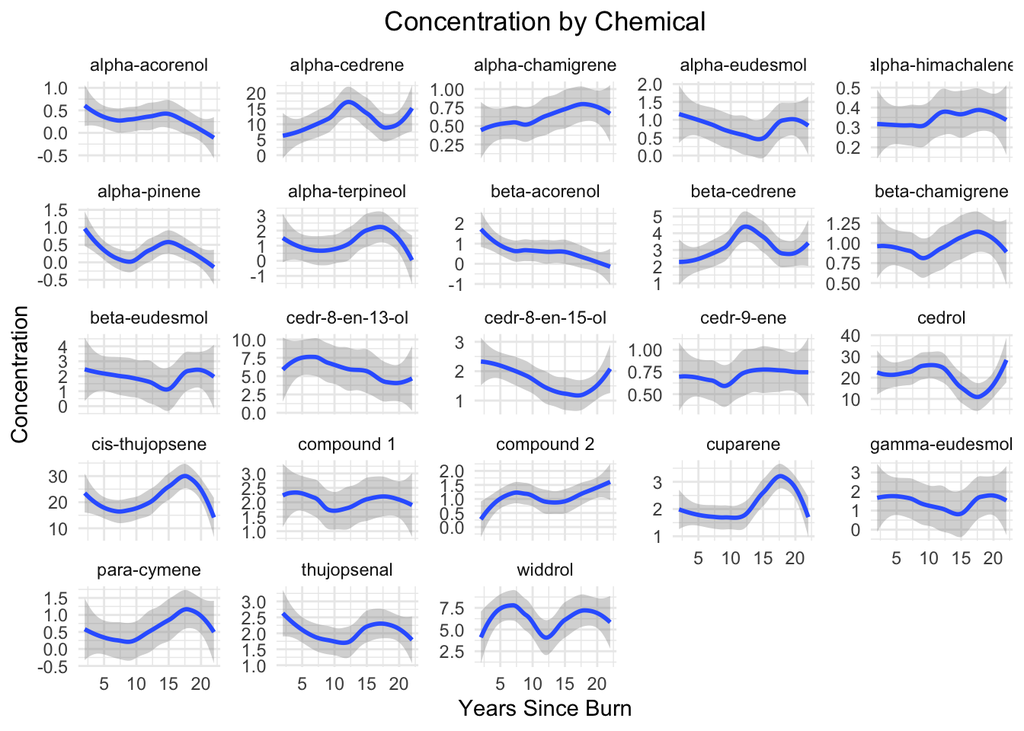

```r
dat2 %>%
  ggplot(aes(x=YearsSinceBurn, y=Concentration)) +
  geom_smooth(method = loess) +
  facet_wrap(~ChemicalID, scales = "free_y") +
  theme_minimal() +
  labs(x = "Years Since Burn",
       title = "Concentration by Chemical") +
  theme(plot.title = element_text(hjust = 0.5))
```

```r
ggsave("./HICKMAN_Fig_2.jpg")
```

Alright, alright. So beauty was an overstatement. Well, isn’t literacy a thing of beauty? I suppose it could’ve been more aesthetically pleasing, but I was feeling lazy (and so were you, apparently.)

## STEP V: Generalized Linear Models Time Baby!

So here I am, in “generalized linear model mode,” trying to be a good scientist and isolate the statistically significant variables, and I realized I get to use interaction!

At last, the moment my ancestors have been waiting for!

```r
mod2 <- glm(data = dat2, formula = Concentration ~ ChemicalID * YearsSinceBurn)
mod2_sum <- summary(mod2)
```

This model was intended to show statistically significant concentrations, as impacted by chemical and time. In other words, to show which chemicals are most likely to rot.

Then came the tidy tibble:

```r
tt <- tidy(mod2)
```

After creating a tibble, I cut out the nasty, insignificant bits, using that same sharp, old blade, subset.

```r
ttss <- tt[c(tt$p.value <= 0.05), ]
```

And meeeeeeeow.

I pushed all files to Github, and here we are. The end of a testy journey, my shining Rmor glistening in the sun. Sharp blade in-hand, aside my trusty steed, it’s on to the real adventure.

Final project, here we come!